[figure not shown]

[OHI British Columbia](http://www.ohibc.org/) | [OHI Science](http://ohi-science.org) | [Citation policy](https://github.com/OHI-Science/ohiprep/releases)

# OHIBC: data_prep_spp.Rmd

Compiled on Wed Nov 18 16:55:06 2015 by ohara

# 1 OHIBC Species Subgoal (Biodiversity)

This script prepares scores (status and trend) for species richness in British Columbia’s coastal regions. Spatial data from IUCN and Aquamaps is combined with extinction risk information from IUCN and conservation rank info based on province-level NatureServe categories.

Currently, the Species Richness sub-goal model is identical to the OHI Global model: a region’s status is based upon an area-weighted average of species health across each BC reporting region.

From Halpern et al (2012):

> The target for the Species sub-goal is to have all species at a risk status of Least Concern. We scaled the lower end of the biodiversity goal to be 0 when 75% species are extinct, a level comparable to the five documented mass extinctions and would constitute a catastrophic loss of biodiversity. The Status of assessed species was calculated as the area- and threat status-weighted average of the number of threatened species within each 0.5 degree grid cell.

**Mean risk status per cell:**

$\bar{R}_{cell} = \frac{\displaystyle\sum_{species}(Risk)}{n_{spp}}$

**Mean risk status per region:**

$\bar{R}_{SPP} = \frac{\displaystyle\sum_{cells}(Y_{cell} * A_{cell} * pA_{cell-rgn})}{A_{rgn}}$

**Species goal model**

$X_{SPP} = \frac{((1 - \bar{R}_{SPP}) - 0.25)}{(1 - 0.25)} * 100%$

where:

- $X_{SPP}$ is Species goal status
- $\bar{R}_{cell}$ is mean extinction risk for one cell
- $\bar{R}_{SPP}$ is area-weighted mean extinction risk for a region
- $A_{cell}$ is cell area
- $pA_{cell-rgn}$ is percent of cell area included in region
- *Risk* is scaled value for species extinction risk category, based on:
  - ‘LC’ = 0.0, ‘NT’ = 0.2, ‘VU’ = 0.4, ‘EN’ = 0.6, ‘CR’ = 0.8, ‘EX’ = 1.0
- SPP trend is calculated in a similar area-weighted mean, but population trend values are assigned according to:
  - ‘Decreasing’ = -0.5, ‘Stable’ = 0.0, ‘Increasing’ = +0.5

# 2 Data Preparation

## 2.1 Data sources

AquaMaps

- From http://www.aquamaps.org/main/home.php: “AquaMaps are computer-generated predictions of natural occurrence of marine species, based on the environmental tolerance of a given species with respect to depth, salinity, temperature, primary productivity, and its association with sea ice or coastal areas.”
- Citation: Kaschner, K., J. Rius-Barile, K. Kesner-Reyes, C.Garilao, S.O. Kullander, T. Rees and R. Froese (2013). AquaMaps: Predicted range maps for aquatic species. World wide web electronic publication, www.aquamaps.org, Version 08/2013.

IUCN Red List spatial data: species range map shapefiles

- Species range map shapefiles downloaded from: http://www.iucnredlist.org/technical-documents/spatial-data
- Citation: IUCN 2014. The IUCN Red List of Threatened Species. Version 2014.1. http://www.iucnredlist.org. Downloaded on 21 September 2015.

IUCN Red List species index: list of all IUCN red list species, incl IUCN species ID and extinction risk category

- Extinction risk categories downloaded from: http://api.iucnredlist.org/index/all.csv
- Habitat and subpopulation information, by species, scraped from: http://www.iucnredlist.org/details//0
- Citation: IUCN 2015. The IUCN Red List of Threatened Species. Version 2015-3. http://www.iucnredlist.org. Downloaded on 9 September 2015.

NatureServe/BC CDC conservation rank info from BC Species and Ecosystems Explorer:

- BC Conservation Data Centre: http://www.env.gov.bc.ca/atrisk/toolintro.html
- NatureServe conservation status: http://explorer.natureserve.org/ranking.htm#global
- Citation: B.C. Conservation Data Centre. 2013. BC Species and Ecosystems Explorer. B.C. Ministry of Environment, Victoria B.C. Available: http://a100.gov.bc.ca/pub/eswp/. Downloaded on 3 August 2015.

NOTE: Davies and Baum (2012) could potentially provide a small number of additional species, as in the California Current OHI, but for now we are not considering this in our assessment.

## 2.2 Load species lookup table from global SPP goal

Currently this uses the global species lookup table. How this list is generated (file locations are in `~/github/ohiprep/globalprep/SPP_ICO`):

- in `ingest_iucn.R`:
  - Pull full IUCN list from http://api.iucnredlist.org/index/all.csv
  - Filter the list to marine species as indicated on each species page
  - Standardize old extinction risk categories
  - Append population trend and parent/subpop info from species web pages
  - Write to `spp_iucn_mar.csv` in git-annex.
- in `spp_fxn.R::create_spp_master_lookup()`:
  - Pull in Aquamaps species information table, create sciname field and standardize categories
  - Pull in IUCN marine species info from `ingest_iucn.R`
  - `full_join()` the two species lists
  - Determine overall category, trend, and spatial info source (preferring IUCN)
  - Remove duplicate records and data-deficient records
  - Convert text extinction risk category and popn trends to number values
  - Identify parent/subpopulations and aliases within `spatial_source` field.

Variables in `spp_all`: am_sid | sciname | am_category | iucn_sid | iucn_category | popn_trend | parent_sid | subpop_sid | popn_category | info_source | spp_group | id_no | spatial_source | category_score | trend_score

Quick glance at global spp_all dataframe:

| sciname | am_sid | iucn_sid | popn_trend | popn_category | spatial_source |
| --- | --- | --- | --- | --- | --- |
| Thymops birsteini | ITS-552925 | 170038 | Unknown | LC | iucn |
| Limulus polyphemus | URM-M-1454 | 11987 | NA | NT | am |
| Auriculastra subula | AFD-Pul-494 | 184918 | Unknown | LC | am |
| Conus stearnsii | ITS-567398 | 192532 | Unknown | VU | iucn |
| Neritina virginea | ITS-70162 | 189436 | Stable | LC | am |
| Conus vexillum | ITS-656358 | 192778 | Unknown | LC | iucn |

## 2.3 Append BC-specific species risk assessment codes

Data downloaded from BC Species and Ecosystems Explorer includes information on global status and provincial status for species, as assessed by NatureServe.

```r
spp_all <- spp_append_bcsee(spp_all)

spp_all <- spp_all %>%
  mutate(iucn_score = category_score,
         category_score = ifelse(!is.na(status_pr_score), status_pr_score, category_score))

write_csv(spp_all, file.path(dir_spp, scenario, 'int/spp_all.csv'))
git_prov(file.path(dir_spp, scenario, 'int/spp_all.csv'), type = 'output')

DT::datatable(spp_all %>%
                dplyr::select(sciname, am_sid, iucn_sid, popn_trend,
                       IUCN_cat = popn_category, NS_cat = status_pr, spatial_source),
              rownames = FALSE,
              caption = 'BC-specific species list:',
              class = 'stripe hover compact',
              options  = list(dom = 'tp'))
```

| sciname | am_sid | iucn_sid | popn_trend | IUCN_cat | NS_cat | spatial_source |
| --- | --- | --- | --- | --- | --- | --- |
| Thymops birsteini | ITS-552925 | 170038 | Unknown | LC |  | iucn |
| Limulus polyphemus | URM-M-1454 | 11987 |  | NT |  | am |
| Auriculastra subula | AFD-Pul-494 | 184918 | Unknown | LC |  | am |
| Conus stearnsii | ITS-567398 | 192532 | Unknown | VU |  | iucn |
| Neritina virginea | ITS-70162 | 189436 | Stable | LC |  | am |
| Conus vexillum | ITS-656358 | 192778 | Unknown | LC |  | iucn |
| Haliotis cracherodii | ITS-69498 | 41880 | Decreasing | CR |  | am |
| Cerithidea pliculosa | ITS-71951 | 189357 | Unknown | LC |  | am |
| Eduarctus martensii | SLB-184905 | 170037 | Unknown | LC |  | iucn |
| Scyllarus pygmaeus | ITS-553024 | 170056 | Unknown | LC |  | iucn |

[output cut: 5628 more lines]

## 2.4 Define assessment regions

Using OHIBC region polygons, determine 0.5° raster cells corresponding to each region.

```
## Reading OHIBC regions shapefile...
##   ~/github/ohibc/prep/regions/ohibc_rgn_wgs84.shp
```

### 2.4.1 Map of region ID per cell

*Note that `subs()` can’t deal with duplicate cell IDs; for cells included in two or more regions, displaying the minimum region ID value*

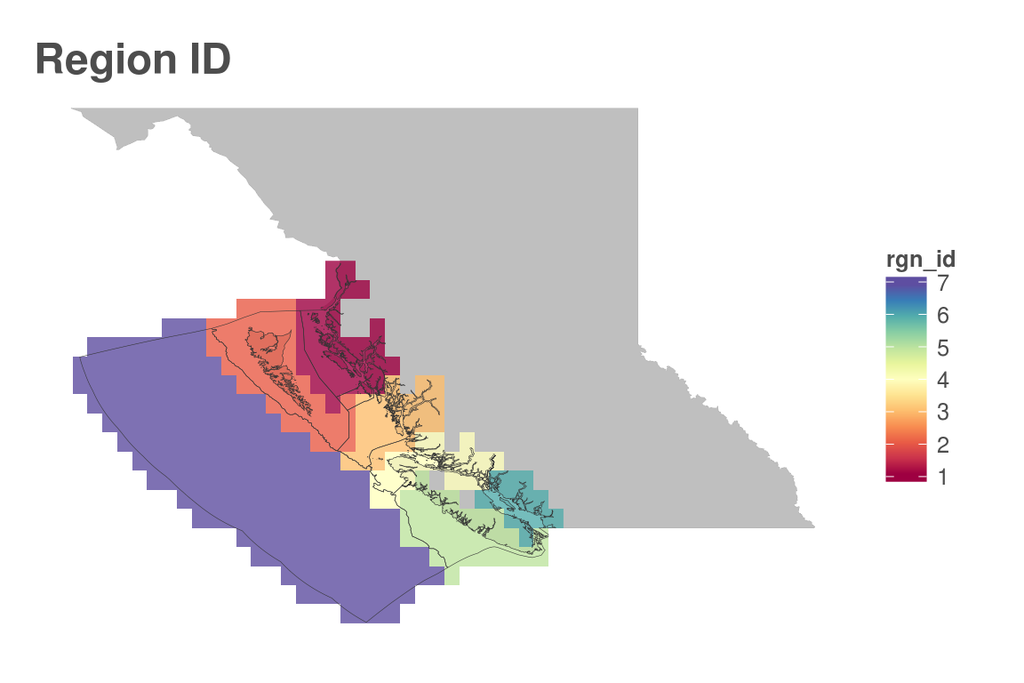

## 2.5 Generate species per cell tables for Aquamaps and IUCN

These species-per-cell tables are generated from global SPP goal data, from AquaMaps data and IUCN range maps, filtered to just OHIBC regions.

| loiczid | mean_cat_score | mean_popn_trend_score | n_cat_species | n_trend_species | source |
| --- | --- | --- | --- | --- | --- |
| 49060 | 0.205263 | -0.136364 | 57 | 44 | aquamaps |
| 49061 | 0.203279 | -0.141304 | 61 | 46 | aquamaps |
| 49780 | 0.171963 | -0.153226 | 107 | 62 | aquamaps |
| 49781 | 0.181818 | -0.15 | 99 | 60 | aquamaps |
| 50494 | 0.150781 | -0.146154 | 128 | 65 | aquamaps |
| 50495 | 0.15124 | -0.129032 | 121 | 62 | aquamaps |
| 50496 | 0.164957 | -0.15625 | 117 | 64 | aquamaps |
| 50497 | 0.163158 | -0.15625 | 114 | 64 | aquamaps |
| 50498 | 0.164602 | -0.15625 | 226 | 128 | aquamaps |
| 50499 | 0.175 | -0.153226 | 104 | 62 | aquamaps |

[output cut: 311 more lines]

| loiczid | mean_cat_score | mean_popn_trend_score | n_cat_species | n_trend_species | source |
| --- | --- | --- | --- | --- | --- |
| 49060 | 0.270588 | 0 | 34 | 23 | iucn |
| 49061 | 0.270588 | 0 | 34 | 23 | iucn |
| 49780 | 0.270588 | 0 | 34 | 23 | iucn |
| 49781 | 0.270588 | 0 | 34 | 23 | iucn |
| 49782 | 0.270588 | 0 | 34 | 23 | iucn |
| 50494 | 0.278788 | 0 | 33 | 22 | iucn |
| 50495 | 0.270588 | 0 | 34 | 23 | iucn |
| 50496 | 0.270588 | 0 | 34 | 23 | iucn |
| 50497 | 0.278788 | 0 | 33 | 22 | iucn |
| 50498 | 0.278788 | 0 | 66 | 44 | iucn |

[output cut: 315 more lines]

### 2.5.1 Map of species count by cell

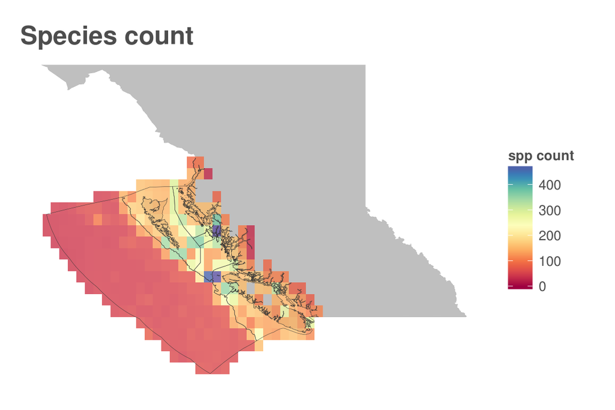

# 3 Calculate goal model

## 3.1 Summarize mean category & trend per cell & region

In this section we perform the model calculations:

- We calculate mean extinction risk score across all species identified in each cell, based on NatureServe province-level rankings where available, and IUCN category ranks elsewhere.
  - IUCN ranks exclude subpopulation scores due to lack of spatially explicit distribution info for subpopulations.
- We calculate mean population trend across all species identified in each cell, based on IUCN population trend information.
- From raster-level summaries, we generate a region-level summary based on area-weighted average extinction risk and population trend.
- From the region-level summary of risk, we determine the SPP goal status based on the goal model equation. SPP trend is identical to the regional average population trend score.

| loiczid | weighted_mean_cat | weighted_mean_trend |
| --- | --- | --- |
| 49060 | 0.229670142857143 | -0.0895524776119403 |
| 49061 | 0.227368536842105 | -0.0942026666666667 |
| 49780 | 0.195744914893617 | -0.111764847058824 |
| 49781 | 0.204511082706767 | -0.108433734939759 |
| 49782 | 0.270588 | 0 |
| 50494 | 0.177018459627329 | -0.109195517241379 |
| 50495 | 0.177419561290323 | -0.0941174588235294 |
| 50496 | 0.188741463576159 | -0.114942528735632 |
| 50497 | 0.189115755102041 | -0.116279069767442 |
| 50498 | 0.190411164383562 | -0.116279069767442 |

[output cut: 315 more lines]

| rgn_id | rgn_mean_cat | rgn_mean_trend | status |
| --- | --- | --- | --- |
| 1 | 0.187331976339864 | -0.112172724752919 | 75.0224031546848 |
| 2 | 0.179948162065616 | -0.100121392889785 | 76.0069117245846 |
| 3 | 0.18168048991445 | -0.0963603152061626 | 75.7759346780734 |
| 4 | 0.180624360135595 | -0.104313897044823 | 75.9167519819207 |
| 5 | 0.187540325751477 | -0.0961519502101122 | 74.9946232331363 |
| 6 | 0.197916359273125 | -0.0861835039580832 | 73.6111520969167 |
| 7 | 0.225651789465271 | -0.129816235098998 | 69.9130947379639 |
| 8 | 0.183127007843649 | -0.104453950659405 | 75.5830656208468 |

### 3.1.1 Map of mean extinction risk category value by cell

*Category value range: least concern = 0, extinct = 1*

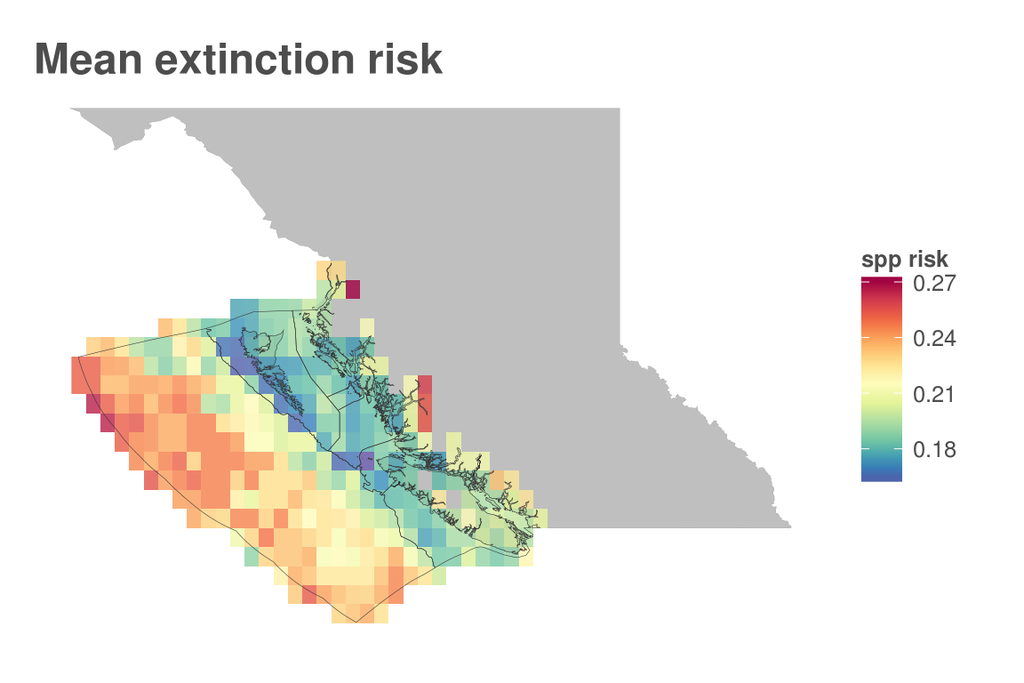

## 3.2 Create and save final output files

Status and trend layers saved to `data` folder.

```
## Writing SPP status and trend based only on IUCN categories to:
##   ~/github/ohibc/prep/spp_ico/v2016/data/spp_status.csv
##   ~/github/ohibc/prep/spp_ico/v2016/data/spp_trend.csv
```

### 3.2.1 Plot map of status by region

The maps and tables show status based upon rankings from NatureServe (where available) and IUCN (where NatureServe is not available). Currently no trend information is taken from NatureServe, so trend is based entirely on IUCN rankings.

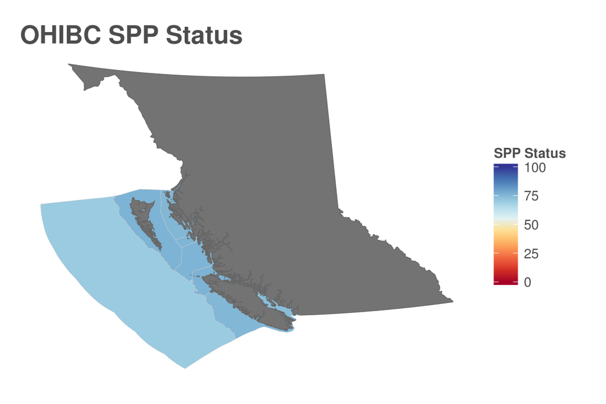

| rgn_id | score | rgn_name | rgn_code | area_km2 | area_hec |
| --- | --- | --- | --- | --- | --- |
| 1 | 75.0224031546848 | North Coast | NC | 17519.9367881726 | 1751993.67881726 |
| 2 | 76.0069117245846 | Haida Gwaii | HG | 46053.7410673043 | 4605374.10673042 |
| 3 | 75.7759346780734 | Central Coast | CC | 20517.0133990465 | 2051701.33990465 |
| 4 | 75.9167519819207 | North Vancouver Island | NV | 13731.5889627591 | 1373158.89627591 |
| 5 | 74.9946232331363 | West Vancouver Island | WV | 28162.4065659818 | 2816240.65659818 |
| 6 | 73.6111520969167 | Strait of Georgia | SG | 8159.22112334552 | 815922.112334552 |
| 7 | 69.9130947379639 | Pacific Offshore | PO | 315888.121302232 | 31588812.1302232 |
| 8 | 75.5830656208468 | Aristazabal Island | AZ | 3210.94773955972 | 321094.773955972 |

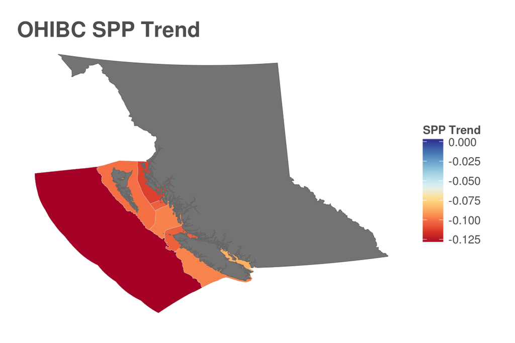

| rgn_id | score | rgn_name | rgn_code | area_km2 | area_hec |
| --- | --- | --- | --- | --- | --- |
| 1 | -0.112172724752919 | North Coast | NC | 17519.9367881726 | 1751993.67881726 |
| 2 | -0.100121392889785 | Haida Gwaii | HG | 46053.7410673043 | 4605374.10673042 |
| 3 | -0.0963603152061626 | Central Coast | CC | 20517.0133990465 | 2051701.33990465 |
| 4 | -0.104313897044823 | North Vancouver Island | NV | 13731.5889627591 | 1373158.89627591 |
| 5 | -0.0961519502101122 | West Vancouver Island | WV | 28162.4065659818 | 2816240.65659818 |
| 6 | -0.0861835039580832 | Strait of Georgia | SG | 8159.22112334552 | 815922.112334552 |
| 7 | -0.129816235098998 | Pacific Offshore | PO | 315888.121302232 | 31588812.1302232 |
| 8 | -0.104453950659405 | Aristazabal Island | AZ | 3210.94773955972 | 321094.773955972 |

## 3.3 Summarize mean category/trend within 3 nm of shore

Create final outputs for 3nm zone for resilience calculations. In this step, rather than using full assessment regions, only the three-nautical-mile offshore zone is examined.

```
## Reading OHIBC 3nm offshore regions shapefile...
##   ~/github/ohibc/prep/regions/ohibc_offshore_3nm_wgs84.shp
```

```
## Writing SPP status and trend for 3nm regions to:
##   ~/github/ohibc/prep/spp_ico/v2016/data/spp_status_3nm.csv
##   ~/github/ohibc/prep/spp_ico/v2016/data/spp_trend_3nm.csv
```

# 4 Provenance

- *Run ID: 1; run tag: “standard run”*
- *Run elapsed time: 220.479 seconds; run memory usage: NA MB*
- *System info: System: Linux, Release: 3.2.0-88-generic. Machine: x86_64. User: ohara.*
- *Session info*
  - *R version: R version 3.2.2 (2015-08-14), Platform: x86_64-pc-linux-gnu, Running under: Ubuntu precise (12.04.5 LTS).*
  - *Attached base packages: stats, graphics, grDevices, utils, datasets, methods, base*
  - *Other attached packages: maptools_0.8-36, RColorBrewer_1.1-2, ggplot2_1.0.1, readr_0.1.1, stringr_1.0.0, tidyr_0.2.0, dplyr_0.4.1, DT_0.1, raster_2.3-40, rgdal_1.0-6, sp_1.1-1*

Provenance summary for this run:

| run_id | run_tag | run_date | file_loc | type | commit_url | commit_author | commit_date | uncommitted_changes |
| --- | --- | --- | --- | --- | --- | --- | --- | --- |
| 1 | standard run | Wed Nov 18 16:58:49 2015 | ~/github/ohibc/prep/spp_ico/R/spp_fxn.R | sourced_script | https://github.com/OHI-Science/ohibc/commit/3a54d7bd19f038b605f2f9d66dd88c27043c980d | Casey O’Hara ohara@nceas.ucsb.edu | Tue Nov 17 18:59:50 2015 -0800 | FALSE |
| 1 | standard run | Wed Nov 18 16:58:49 2015 | /var/data/ohi/git-annex/globalprep/SPP_ICO/v2015/intermediate/spp_all.csv | input | no version control info found | NA | NA | TRUE |
| 1 | standard run | Wed Nov 18 16:58:49 2015 | /var/data/ohi/git-annex/bcprep/data/bc_species_and_ecosystems_explorer/bcsee_export.tsv | input | no version control info found | NA | NA | TRUE |
| 1 | standard run | Wed Nov 18 16:58:49 2015 | ~/github/ohibc/prep/regions/ohibc_rgn_wgs84.shp | input | https://github.com/OHI-Science/ohibc/commit/b014927db4445d63bc01ddf683252c301cd59d0f | Casey O’Hara ohara@nceas.ucsb.edu | Wed Oct 28 11:55:33 2015 -0700 | FALSE |
| 1 | standard run | Wed Nov 18 16:58:49 2015 | ~/github/ohibc/prep/spp_ico/v2016/int/cell_id_by_rgn.csv | input | https://github.com/OHI-Science/ohibc/commit/b014927db4445d63bc01ddf683252c301cd59d0f | Casey O’Hara ohara@nceas.ucsb.edu | Wed Oct 28 11:55:33 2015 -0700 | FALSE |
| 1 | standard run | Wed Nov 18 16:58:49 2015 | ~/github/ohibc/prep/spp_ico/v2016/int/am_cells_spp_prob0.csv | input | https://github.com/OHI-Science/ohibc/commit/b014927db4445d63bc01ddf683252c301cd59d0f | Casey O’Hara ohara@nceas.ucsb.edu | Wed Oct 28 11:55:33 2015 -0700 | FALSE |
| 1 | standard run | Wed Nov 18 16:58:49 2015 | ~/github/ohibc/prep/spp_ico/v2016/summary/spp_sum_am_cells.csv | input | https://github.com/OHI-Science/ohibc/commit/daf48fa3731dfbf324fbede879dbb4b4817422a5 | Casey O’Hara ohara@nceas.ucsb.edu | Wed Oct 28 15:04:01 2015 -0700 | FALSE |
| 1 | standard run | Wed Nov 18 16:58:49 2015 | ~/github/ohibc/prep/spp_ico/v2016/summary/spp_sum_iucn_cells.csv | input | https://github.com/OHI-Science/ohibc/commit/daf48fa3731dfbf324fbede879dbb4b4817422a5 | Casey O’Hara ohara@nceas.ucsb.edu | Wed Oct 28 15:04:01 2015 -0700 | FALSE |
| 1 | standard run | Wed Nov 18 16:58:49 2015 | ~/github/ohibc/prep/regions/ohibc_offshore_3nm_wgs84.shp | input | https://github.com/OHI-Science/ohibc/commit/b014927db4445d63bc01ddf683252c301cd59d0f | Casey O’Hara ohara@nceas.ucsb.edu | Wed Oct 28 11:55:33 2015 -0700 | FALSE |
| 1 | standard run | Wed Nov 18 16:58:49 2015 | ~/github/ohibc/prep/spp_ico/v2016/int/cell_id_by_rgn_3nm.csv | input | https://github.com/OHI-Science/ohibc/commit/b014927db4445d63bc01ddf683252c301cd59d0f | Casey O’Hara ohara@nceas.ucsb.edu | Wed Oct 28 11:55:33 2015 -0700 | FALSE |
| 1 | standard run | Wed Nov 18 16:58:49 2015 | ~/github/ohibc/prep/spp_ico/v2016/int/spp_all.csv | output | Previous commit: https://github.com/OHI-Science/ohibc/commit/37892bca2331dfe191779c89ba3c6885e4fdec58 | Casey O’Hara ohara@nceas.ucsb.edu | Fri Oct 30 15:53:11 2015 -0700 | FALSE |
| 1 | standard run | Wed Nov 18 16:58:49 2015 | ~/github/ohibc/prep/spp_ico/v2016/data/spp_status.csv | output | Previous commit: https://github.com/OHI-Science/ohibc/commit/37892bca2331dfe191779c89ba3c6885e4fdec58 | Casey O’Hara ohara@nceas.ucsb.edu | Fri Oct 30 15:53:11 2015 -0700 | FALSE |
| 1 | standard run | Wed Nov 18 16:58:49 2015 | ~/github/ohibc/prep/spp_ico/v2016/data/spp_trend.csv | output | Previous commit: https://github.com/OHI-Science/ohibc/commit/37892bca2331dfe191779c89ba3c6885e4fdec58 | Casey O’Hara ohara@nceas.ucsb.edu | Fri Oct 30 15:53:11 2015 -0700 | FALSE |
| 1 | standard run | Wed Nov 18 16:58:49 2015 | ~/github/ohibc/prep/spp_ico/v2016/data/spp_status_3nm.csv | output | Previous commit: https://github.com/OHI-Science/ohibc/commit/37892bca2331dfe191779c89ba3c6885e4fdec58 | Casey O’Hara ohara@nceas.ucsb.edu | Fri Oct 30 15:53:11 2015 -0700 | FALSE |
| 1 | standard run | Wed Nov 18 16:58:49 2015 | ~/github/ohibc/prep/spp_ico/v2016/data/spp_trend_3nm.csv | output | Previous commit: https://github.com/OHI-Science/ohibc/commit/37892bca2331dfe191779c89ba3c6885e4fdec58 | Casey O’Hara ohara@nceas.ucsb.edu | Fri Oct 30 15:53:11 2015 -0700 | FALSE |
| 1 | standard run | Wed Nov 18 16:58:49 2015 | ~/github/ohibc/prep/spp_ico/data_prep_spp.Rmd | script | https://github.com/OHI-Science/ohibc/commit/3a54d7bd19f038b605f2f9d66dd88c27043c980d | Casey O’Hara ohara@nceas.ucsb.edu | Tue Nov 17 18:59:50 2015 -0800 | FALSE |